# Final report

Tianhao Wu

2025-03-15

# Abstract

Our goal for this project is to find out which predictors are important for predicting the feedback of mice. In this report, I will explore each variable’s meanings and figure out the data structures. Also, I will find out the relationships between some variables corresponding to each feedback type to extract the variable features. Then, I will combine those featured variable(correlated with feedbacktype) as a integrated dataframe and filter out unnecessary predictors with cross-validation. Finally, we create the high-performanced predictive model with high accuracy, proving that it has excellent capabilities in prediction.

# introduction:

In this project, we analyze a portion of data collected by Steinmetz et al. (2019). While this file(session.zip) provides a brief structure of the experiments, referring to the original studies will help me obtain a deeper understanding and improve my quality of the analysis. The study involved 10 mice over 39 experimental sessions. In each session, the mice completed several hundred different trials where visual stimuli appeared on two screens, one on each side, and the stimuli had different contrast levels: 0 (no stimulus), 0.25, 0.5, and 1. The mice will use a wheel controlled by their forepaws to respond to the stimuli. Based on their decisions, they will receive either a reward (for correct choices) or a penalty (for incorrect ones). The rules for correct choices were: a)If the left contrast was higher than the right, the response is turning the wheel to the right. b)If the right contrast was higher than the left, the response is turning the wheel to the left. c)If no stimulus appeared on either side (both contrasts were 0), the response is to keep the wheel still. d)If both contrasts are equal but non-zero, the response is randomly assigned (ie.50% left, 50% right). During each trial, the activity of neuron activity in the mice’s was recorded in the form of spike trains. So, in this project, I’ll focus on the the feature of variable(such as: neural activities with respect to time). The data was from 1st session(Sessions 1–18) involving four mice: Cori(1st session), Frossman, Hence, and Lederberg.

## Data structure

A total of 18 RDS files are provided that contain the records from 18 sessions. In each RDS file, you can find the name of mouse from `mouse_name` and date of the experiment from `date_exp`.

```r
session=list()
session <- lapply(1:18, function(i) {
  readRDS(paste("C:\\Users\\Administrator\\Desktop\\STA 141 A retake\\project\\sessions\\session", i, '.rds', sep = ''))
})
```

Take the 11th trial in Session 5 for example, we can see that the left contrast for this trial is 1 the right contrast is 0, and the feedback (i.e., outcome) of the trial is 1. There are a total of 1077 neurons in this trial from 10 areas of the brain. The spike trains of these neurons are stored in `session[[5]]$spks[[11]]` which is a 1077 by 40 matrix with each entry being the number of spikes of one neuron (i.e., row) in each time bin (i.e., column).

```r
session[[5]]$contrast_left[11]
```

```
## [1] 1
```

```r
session[[5]]$contrast_right[11]
```

```
## [1] 0
```

```r
session[[5]]$feedback_type[11]
```

```
## [1] 1
```

# Question of interest

The primary objective of this project is to build a predictive model to predict the outcome (i.e., feedback type) of each trial using the neural activity data (i.e., spike trains in `spks`), along with the stimuli (the left and right contrasts). Given the complexity of the data (and that this is a course project), we break the predictive modeling into three parts as follows.

## Part 1. Exploratory data analysis.

In this part, we will explore the features of the data sets in order to build our prediction model. In particular, we would like choose the first session to observe the data structure to figure out what each variable means.

### Display the variable informations throughout each session

```r
names(session[[1]])
```

```
## [1] "contrast_left"  "contrast_right" "feedback_type"  "mouse_name"
## [5] "brain_area"     "date_exp"       "spks"           "time"
```

- `feedback_type`: type of the feedback, 1 for success and -1 for failure
- `contrast_left`: contrast of the left stimulus
- `contrast_right`: contrast of the right stimulus
- `time`: centers of the time bins for `spks`
- `spks`: numbers of spikes of neurons in the visual cortex in time bins defined in `time`
- `brain_area`: area of the brain where each neuron lives

### number of neurons/trails in the first session

```r
length(session[[1]]$spks)
```

```
## [1] 114
```

### the number of trail of session 1 is 114

```r
length(session[[1]]$contrast_left)
```

```
## [1] 114
```

```r
length(session[[1]]$contrast_right)
```

```
## [1] 114
```

### extract feedback type information in first session

```r
Session1_report<-data.frame(Contrast_left=session[[1]]$contrast_left,Contrast_right=session[[1]]$contrast_right,Feedback=session[[1]]$feedback_type)
Session1_report$Feedback<-ifelse(Session1_report$Feedback==1,"success","failure")
Session1_report$result<-ifelse(Session1_report$Feedback=="success","right","left")
unique(Session1_report$Feedback)
```

```
## [1] "success" "failure"
```

## Make summary output for all information of mice in first session

[output not shown]

## Session 1 Data Analysis

In the first session, the mice name is the Cori. We are going to explore the information variable and their structures.

### The name of each brain area in first session

```r
#for each session, the mice has different simulation of the brain area
unique(session[[1]]$brain_area)
```

```
## [1] "ACA"  "MOs"  "LS"   "root" "VISp" "CA3"  "SUB"  "DG"
```

### The dimention of the brain area, the time for the first trail, the spikes of the first trail

```r
length(session[[1]]$brain_area)#the stimuli of brain area for each trail
```

```
## [1] 734
```

```r
length(session[[1]]$time[[1]])#the time bins for each trail
```

```
## [1] 40
```

```r
dim(session[[1]]$spks[[1]])#the number of neurons in each time bin for each trail
```

```
## [1] 734  40
```

Since the dimention of the spike is the same as the brain_area x matrix, we conclude the spike matrix is the summary of the number in each brain area for the first trail with 40 time bins.

### Make a summary result of each frequency of brain area in first trail of the first session

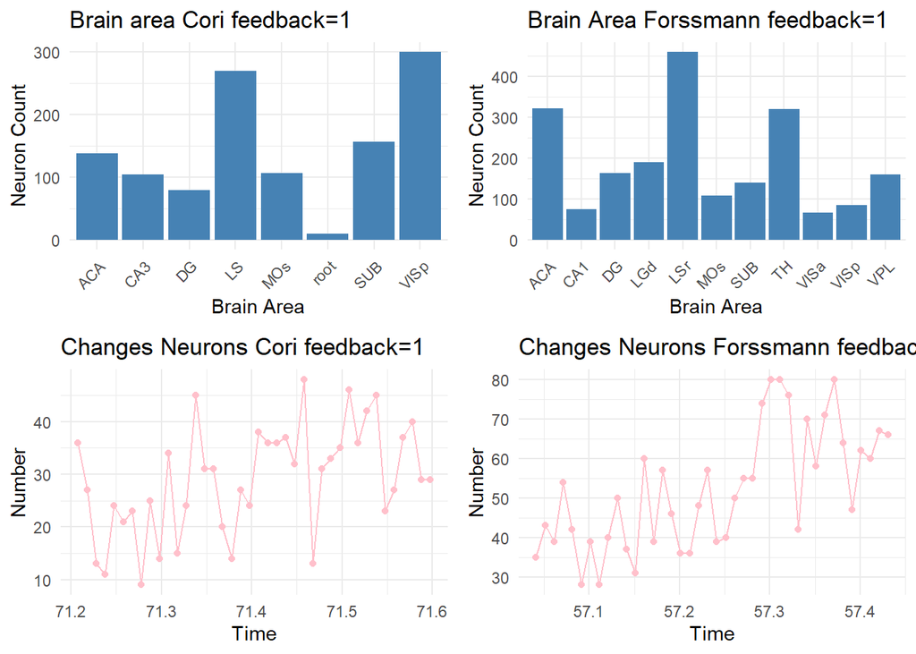

```r
library(gridExtra)
grid.arrange(plt1, plt2,chag1,chag2, nrow=2, ncol = 2)
```

-The difference of Neurons change between Mice in the histogram, they explains the frequency of each brain area appears in the first trail of the first session for each mice

-In the line plot, they explains the changes of neurons in over time for each mice. In the histogram, they explains the frequency of each brain area appears in the first trail of the first session for each mice

### changes Neurons Across feedback type

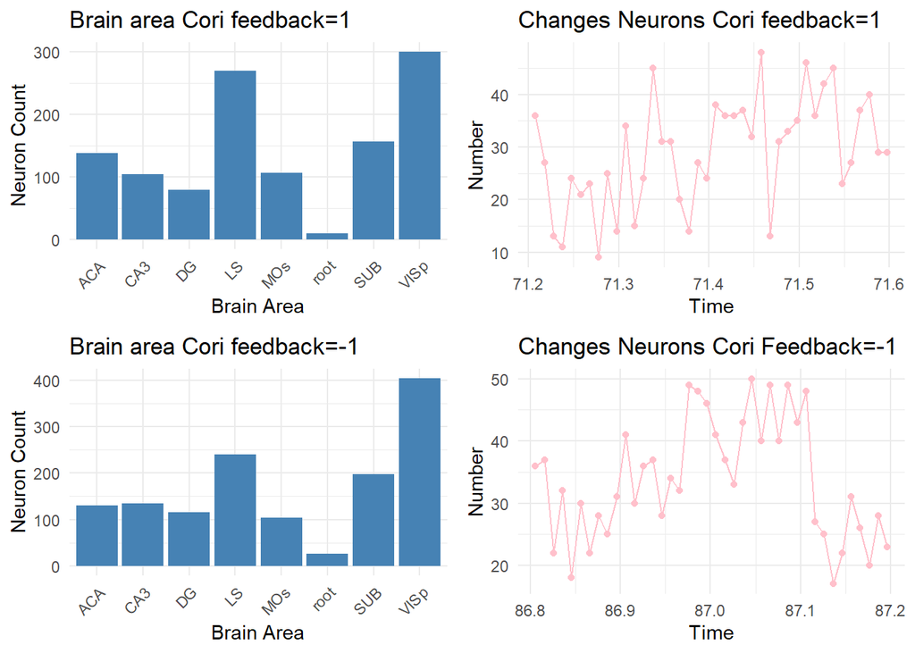

It seems that the brain area may not affect the cori’s feedback type in this sestion, however, the changes of neuron is different between feedback type 1 and -1, which means the neuron activity may be a factor influence feedback type, so we need Time series analysis next.

### changes in success rate for each mice

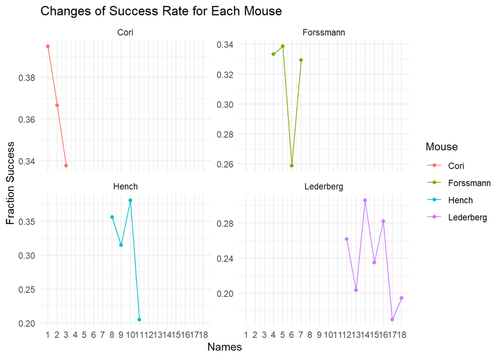

Each Mice has different performance(success rate) across the sessions, which means the success rate of the mice could change over the date.

### Observe the brain_area change in the first trail of different mice

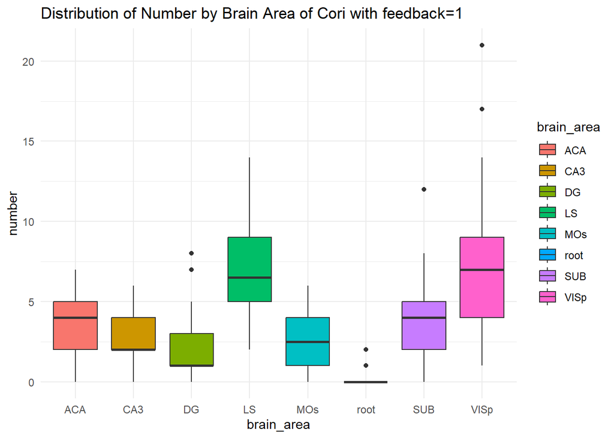

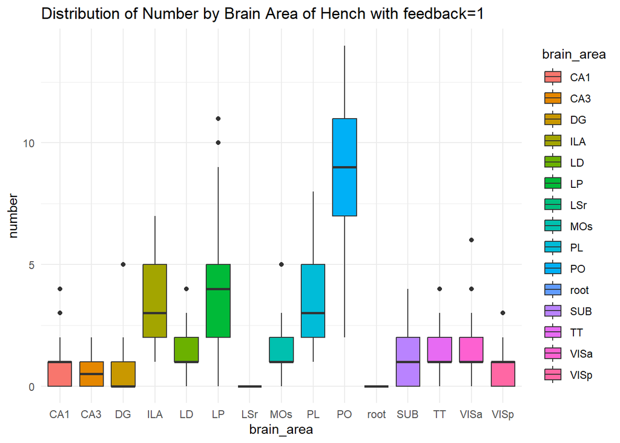

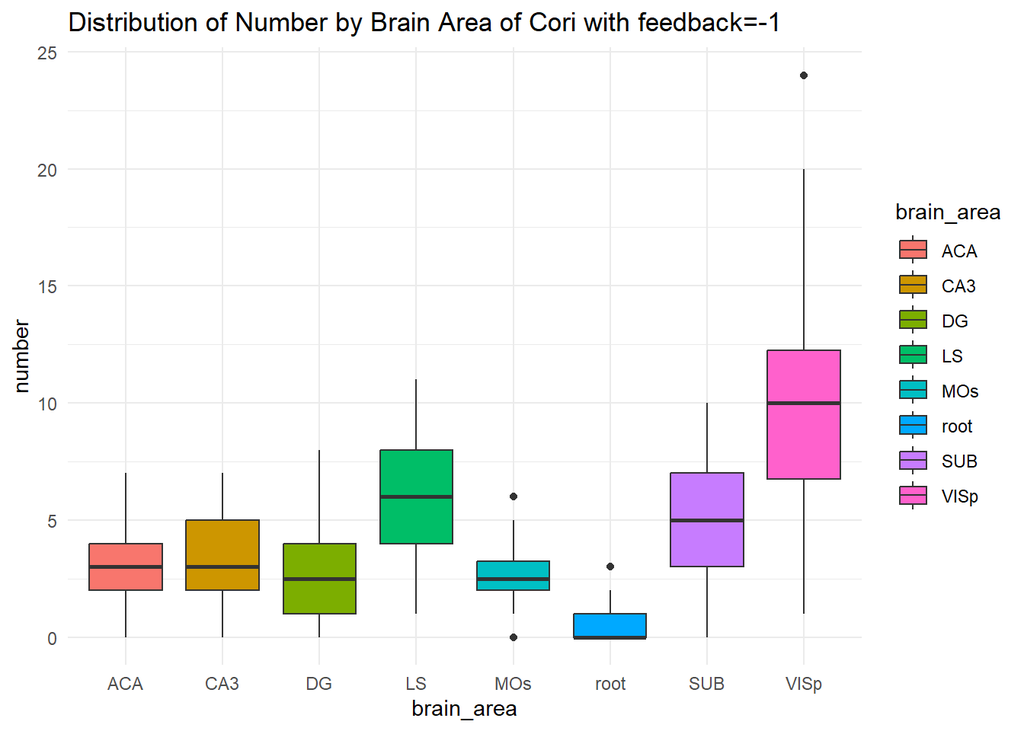

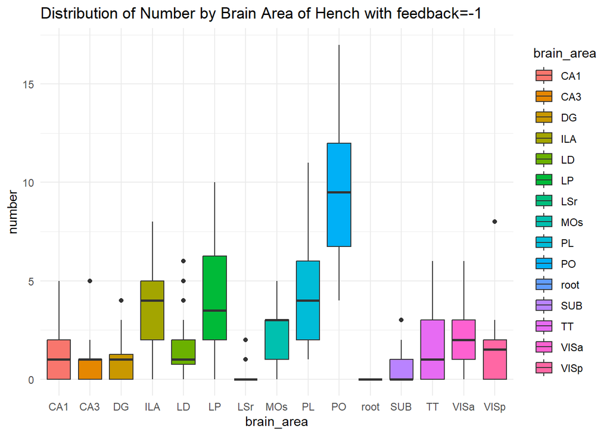

The distribution of brain area is different between mice. Also, the distribution of feedback=1 is different from feedback=-1, meaning the difference of neuron activity could be a factor affecting the feedback type.

## Part 2. Feature extraction

### Brief features I extracted from the whole session data

```
## 'data.frame':    5081 obs. of  8 variables:
##  $ contrast_left : num  0 0 0.5 0 0 0 1 0.5 0 0.5 ...
##  $ contrast_right: num  0.5 0 1 0 0 0 0.5 0 0 0.25 ...
##  $ feedback_type : num  1 1 -1 -1 -1 1 1 1 1 1 ...
##  $ session_id    : int  1 1 1 1 1 1 1 1 1 1 ...
##  $ mouse_name    : chr  "Cori" "Cori" "Cori" "Cori" ...
##  $ date_exp      : chr  "2016-12-14" "2016-12-14" "2016-12-14" "2016-12-14" ...
##  $ time          : num  71.2 81.2 86.8 96 99.6 ...
##  $ spike_count   : int  29360 29360 29360 29360 29360 29360 29360 29360 29360 29360 ...
```

```
##   contrast_left contrast_right feedback_type session_id mouse_name   date_exp
## 1           0.0            0.5             1          1       Cori 2016-12-14
## 2           0.0            0.0             1          1       Cori 2016-12-14
## 3           0.5            1.0            -1          1       Cori 2016-12-14
## 4           0.0            0.0            -1          1       Cori 2016-12-14
## 5           0.0            0.0            -1          1       Cori 2016-12-14
## 6           0.0            0.0             1          1       Cori 2016-12-14
##        time spike_count
## 1  71.20770       29360
## 2  81.24026       29360
## 3  86.80595       29360
## 4  95.98930       29360
## 5  99.55575       29360
## 6 105.57145       29360
```

Since the spike count is the same along each trail of the session of the Mice, we need to explore more information about spike_count

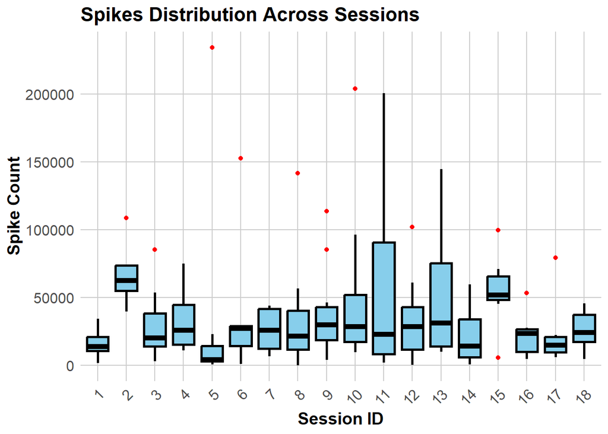

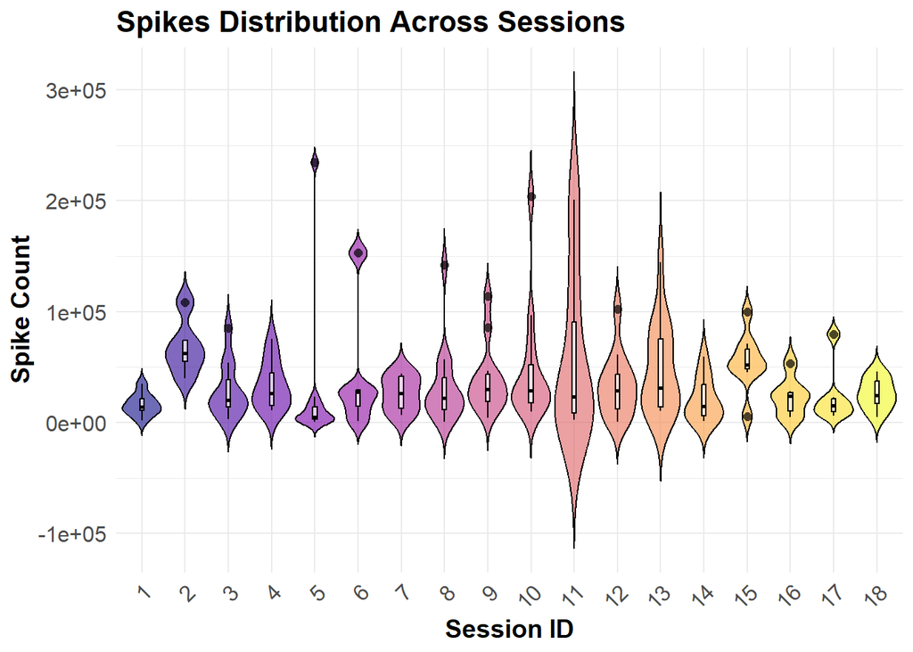

The Spike distribution is different across the sessions, which means the spike count could be a factor affecting the feedback type, so we need to calculate the spike ratio as a important feature for the prediction model.

### Extract information of occurence of each brain area of each trail(Y or N)

```
##   ACA MOs LS root VISp CA3 SUB DG CA1 VISl VISpm POST VISam MG SPF LP MRN NB
## 1   1   1  1    1    1   1   1  1   0    0     0    0     0  0   0  0   0  0
## 2   1   1  1    1    1   1   1  1   0    0     0    0     0  0   0  0   0  0
## 3   1   1  1    1    1   1   1  1   0    0     0    0     0  0   0  0   0  0
## 4   1   1  1    1    1   1   1  1   0    0     0    0     0  0   0  0   0  0
## 5   1   1  1    1    1   1   1  1   0    0     0    0     0  0   0  0   0  0
## 6   1   1  1    1    1   1   1  1   0    0     0    0     0  0   0  0   0  0
##   LGd TH VPL VISa LSr OLF ORB PL AUD SSp LD CP EPd PIR ILA TT PO ORBm MB SCm
## 1   0  0   0    0   0   0   0  0   0   0  0  0   0   0   0  0  0    0  0   0
## 2   0  0   0    0   0   0   0  0   0   0  0  0   0   0   0  0  0    0  0   0
## 3   0  0   0    0   0   0   0  0   0   0  0  0   0   0   0  0  0    0  0   0
## 4   0  0   0    0   0   0   0  0   0   0  0  0   0   0   0  0  0    0  0   0
## 5   0  0   0    0   0   0   0  0   0   0  0  0   0   0   0  0  0    0  0   0
## 6   0  0   0    0   0   0   0  0   0   0  0  0   0   0   0  0  0    0  0   0
##   SCsg POL GPe VISrl MOp LSc PT MD LH ZI SCs RN MS RSP PAG BLA VPM SSs RT MEA
## 1    0   0   0     0   0   0  0  0  0  0   0  0  0   0   0   0   0   0  0   0
## 2    0   0   0     0   0   0  0  0  0  0   0  0  0   0   0   0   0   0  0   0
## 3    0   0   0     0   0   0  0  0  0  0   0  0  0   0   0   0   0   0  0   0
## 4    0   0   0     0   0   0  0  0  0  0   0  0  0   0   0   0   0   0  0   0
## 5    0   0   0     0   0   0  0  0  0  0   0  0  0   0   0   0   0   0  0   0
## 6    0   0   0     0   0   0  0  0  0  0   0  0  0   0   0   0   0   0  0   0
##   ACB OT SI SNr
## 1   0  0  0   0
## 2   0  0  0   0
## 3   0  0  0   0
## 4   0  0  0   0
## 5   0  0  0   0
## 6   0  0  0   0
```

After doing the distributions, we also consider the effect of brain area in each trail for detailed. That is because the occurence of the some brain areas for a mice(like Cori) might appear in another mice(such as root in Hench)

## Time Series

Follow the question we talked about in comparison of changes of Neurons, we would like to extract the time series data to see how the neuron activity changes over time, extracting AR1 as the time coefficient for session 1, extract how much the current neuron spike count depends on the previous one.

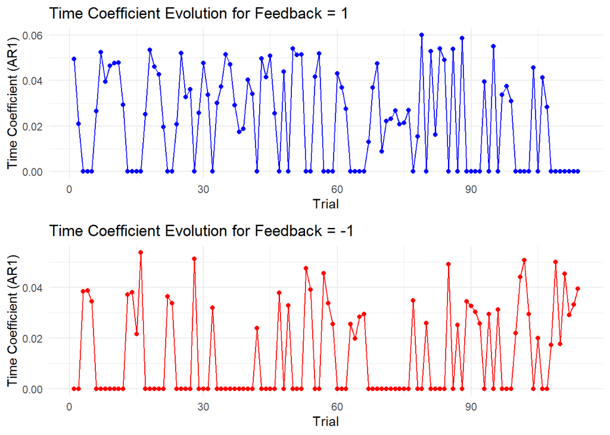

```
##    Trial Time_Coefficient_Feedback_1 Time_Coefficient_Feedback_neg1
## 1      1                  0.04932131                     0.00000000
## 2      2                  0.02100489                     0.00000000
## 3      3                  0.00000000                     0.03837891
## 4      4                  0.00000000                     0.03875380
## 5      5                  0.00000000                     0.03435476
## 6      6                  0.02644234                     0.00000000
## 7      7                  0.05242661                     0.00000000
## 8      8                  0.03937292                     0.00000000
## 9      9                  0.04652039                     0.00000000
## 10    10                  0.04770585                     0.00000000
```

### Note:

The time coefficient in this plot represents the AR(1) value from an ARIMA(1,0,0) model fitted to each trial’s neural activity. ### Analysis: Since the Time_coefficient(AR(1))is not high, there is more random neuron spikes in the first session(low memory effect), the plots displays that AR(1) fluctuates a lot over time, which means neuron responses might be influenced by other external factors (stimuli.etc).

## Part 2. Data integration.

Using the findings in Part 1, we will propose an approach to combine data across trials by (i) extracting the shared patterns across sessions and/or (ii) addressing the differences between sessions. The goal of this part is to enable the borrowing of information across sessions to enhance the prediction performance in Part 3.

### load all sessions time coefficient, construct the final dataframe for data integration

```
## # A tibble: 6 × 75
##   mouse_name contrast_left[,1] contrast_right[,1] feedback_type[,1] session_id
##   <chr>                  <dbl>              <dbl>             <dbl>      <int>
## 1 Cori                     0                  0.5                 1          1
## 2 Cori                     0                  0                   1          1
## 3 Cori                     0.5                1                  -1          1
## 4 Cori                     0                  0                  -1          1
## 5 Cori                     0                  0                  -1          1
## 6 Cori                     0                  0                   1          1
## # ℹ 70 more variables: trial_id <int>, total_neurons <int>, total_spikes <dbl>,
## #   spike_ratio <dbl>, num_brain_areas <int>, session_spike_max <dbl>,
## #   session_spike_min <dbl>, ACA <dbl>, MOs <dbl>, LS <dbl>, root <dbl>,
## #   VISp <dbl>, CA3 <dbl>, SUB <dbl>, DG <dbl>, CA1 <dbl>, VISl <dbl>,
## #   VISpm <dbl>, POST <dbl>, VISam <dbl>, MG <dbl>, SPF <dbl>, LP <dbl>,
## #   MRN <dbl>, NB <dbl>, LGd <dbl>, TH <dbl>, VPL <dbl>, VISa <dbl>, LSr <dbl>,
## #   OLF <dbl>, ORB <dbl>, PL <dbl>, AUD <dbl>, SSp <dbl>, LD <dbl>, CP <dbl>, …
```

### Extract important features after hyperparameter tuning

```
## [1] "Number of parameters with importance > 1: 20"
```

```
##  [1] "Feedback_time"       "total_spikes"        "spike_ratio"
##  [4] "contrast_right"      "contrast_left"       "session_spike_min"
##  [7] "session_spike_max"   "total_neurons"       "num_brain_areas"
## [10] "mouse_nameLederberg" "LSr"                 "root"
## [13] "MOs"                 "PL"                  "VISp"
## [16] "CA3"                 "VISl"                "ACA"
## [19] "POST"                "DG"
```

### Diagonistics

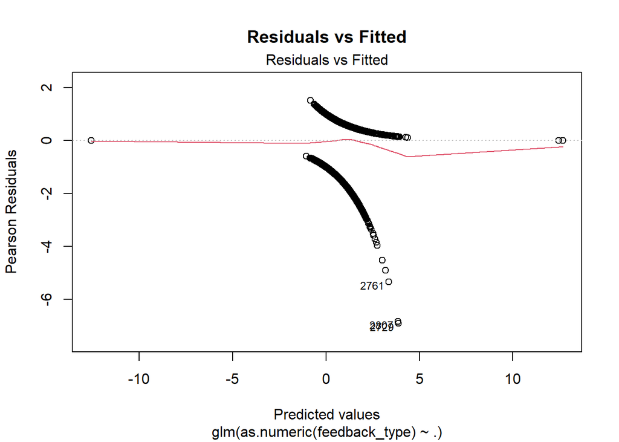

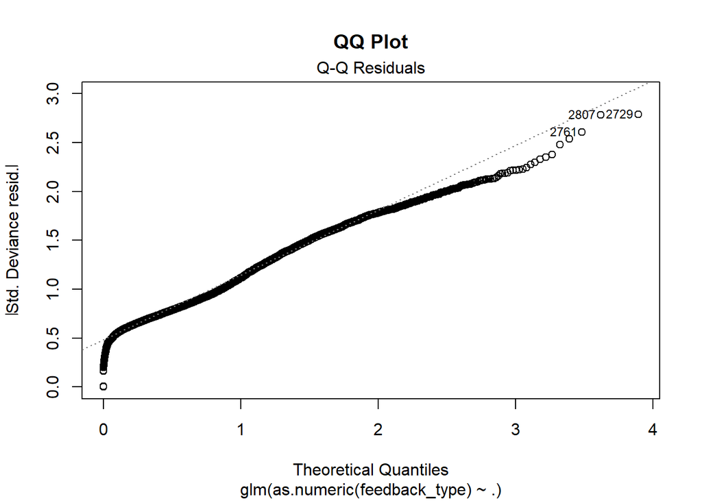

The residuals vs. fitted plot and the normal QQ plot displays that the data is not accurately centered(since there is a strong deviation from 0 to 5, which means the model has biased prediction ). But the residuals are closer to the regression line as the value decreased. We can observe three outliers:2761,2807,2729. Therefore, the logistic regression model are no longer fitted in this case. So, we need have attempt on Random Forest Model.

### Model training performance

```
##
## Call:
##  randomForest(formula = feedback_type ~ ., data = train_data,      mtry = 4, ntree = 900, importance = TRUE)
##                Type of random forest: classification
##                      Number of trees: 900
## No. of variables tried at each split: 4
##
##         OOB estimate of  error rate: 27.45%
## Confusion matrix:
##     -1    1 class.error
## -1 193  986  0.83630195
## 1  130 2757  0.04502944
```

```
##  [1] "Feedback_time"     "total_spikes"      "spike_ratio"
##  [4] "contrast_right"    "contrast_left"     "session_spike_min"
##  [7] "session_spike_max" "total_neurons"     "num_brain_areas"
## [10] "mouse_name"        "LSr"               "root"
## [13] "MOs"               "PL"                "VISp"
## [16] "CA3"               "VISl"              "ACA"
## [19] "POST"              "DG"
```

### Analysis of the model with 20% test dataset split from original data

```
## [1] "Test accuracy: 74.58 %"
```

```
## [1] "Confusion Matrix:"
```

```
##       Predicted
## Actual  -1   1
##     -1  61 233
##     1   25 696
```

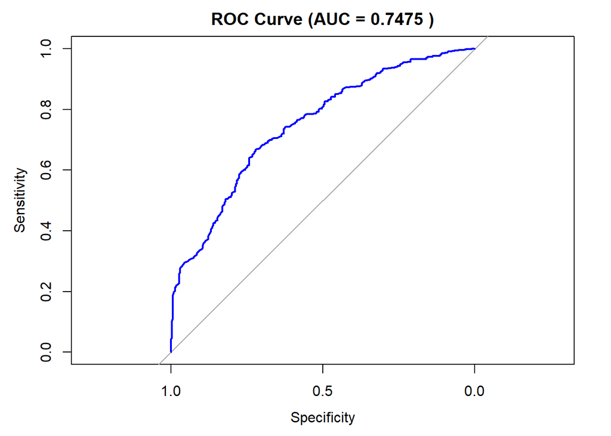

```
## [1] "AUC: 0.7475"
```

### Analysis of the performance in Instructor’s test data

```
## [1] "Confusion Matrix (Sessions 1 and 2):"
```

```
##       Predicted
## Actual  -1   1
##     -1  70  67
##     1    6 222
```

```
## [1] "Test accuracy (Sessions 1 and 2): 80 %"
```

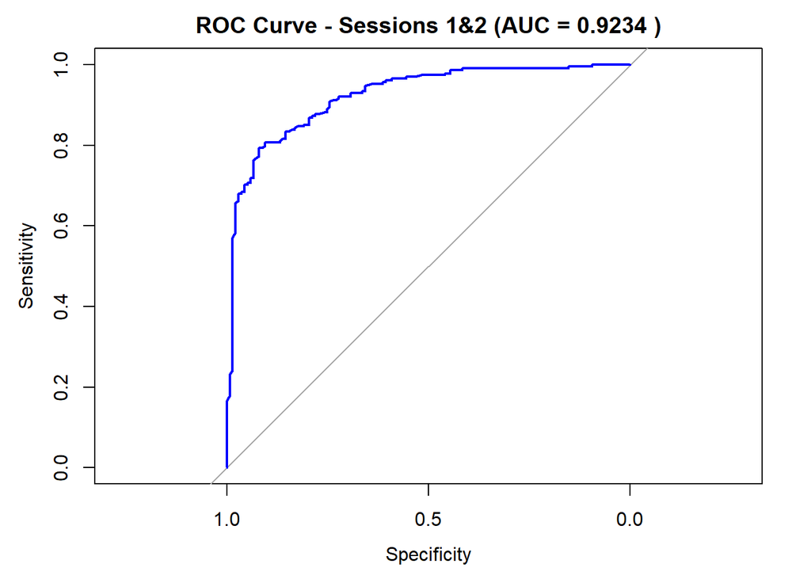

```
## [1] "AUC (Sessions 1 and 2): 0.9234"
```

The test accuracy is 0.8 (ie.The model correctly predicts the class in 80% of cases.), which is a good improvement of our model. The AUC is 0.9234, which indicates that the model has strong ability to predict the values of feedback_type.

# Appendix

## what I discovered but not used in the model

### Changes of Each brain area of Mice Cori in the first trail in session one with respect to time

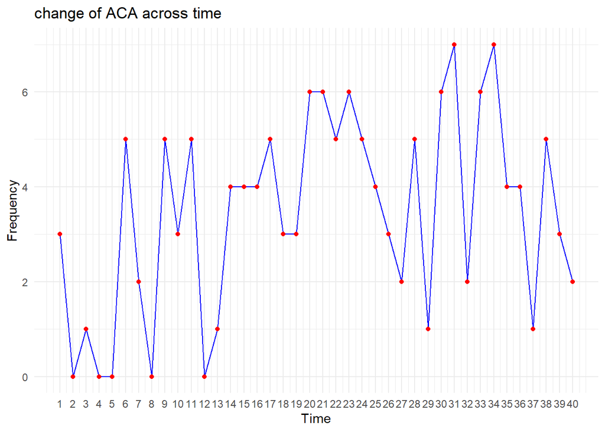

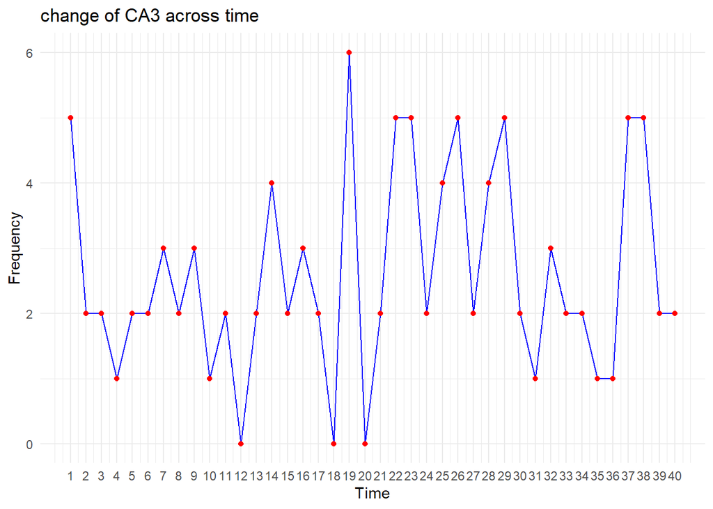

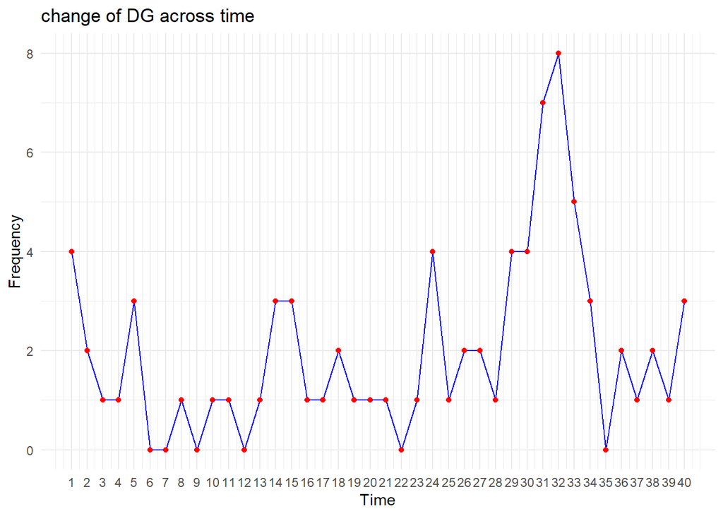

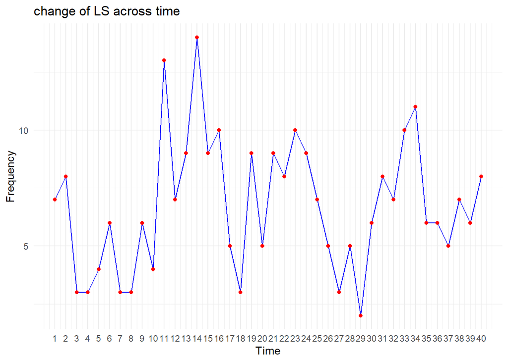

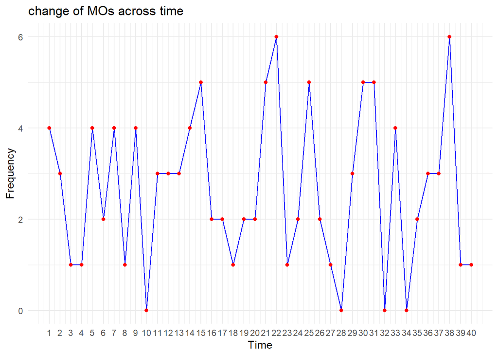

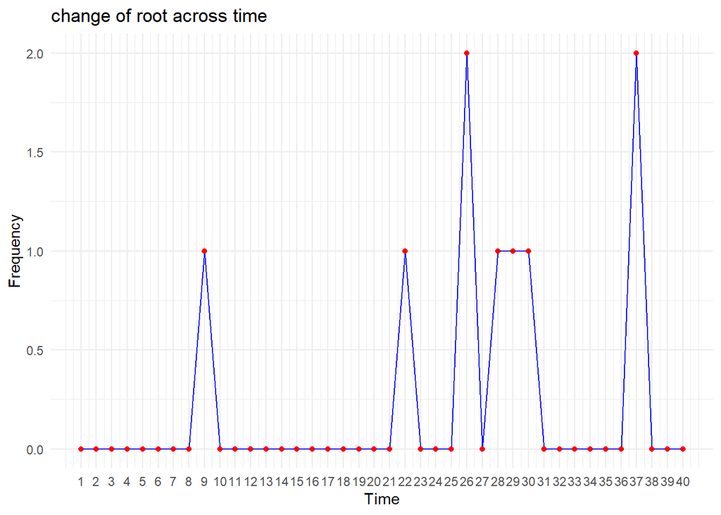

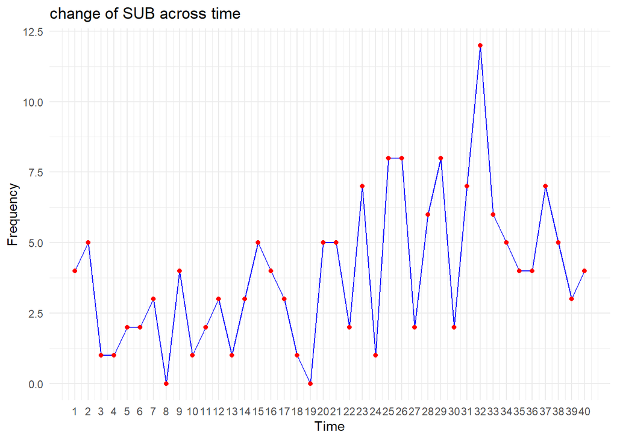

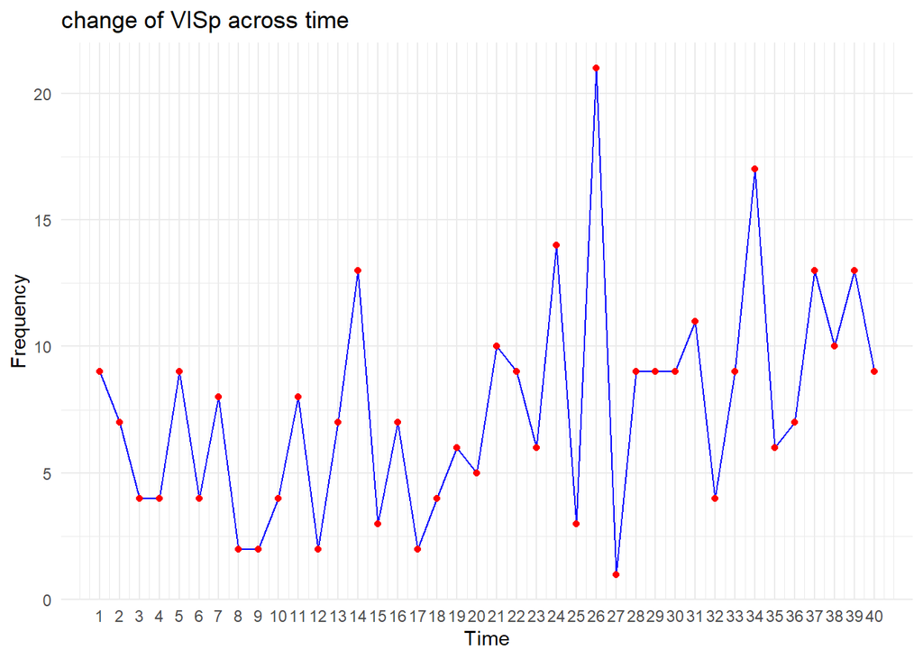

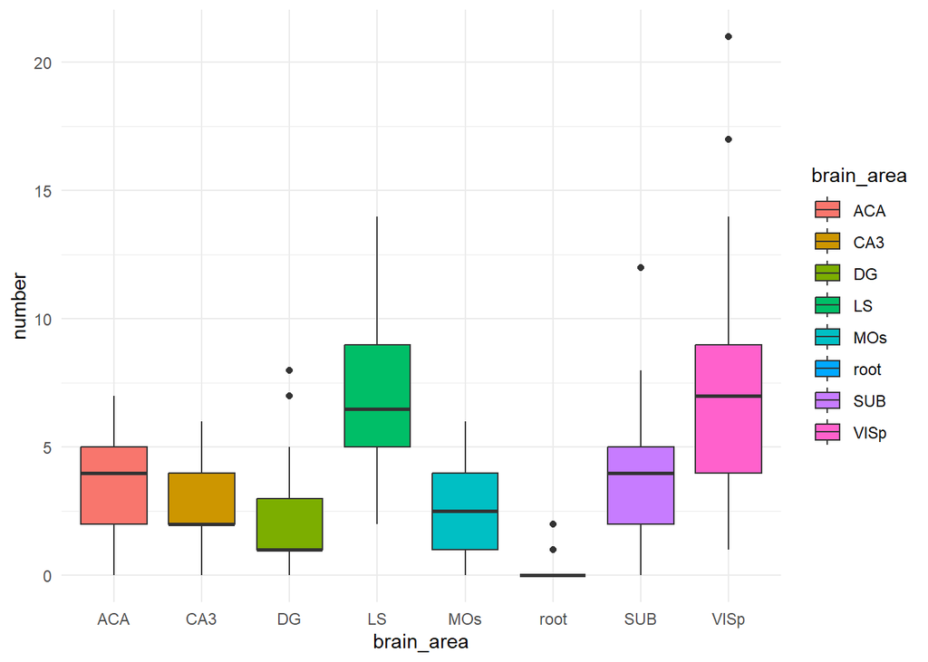

### The Mean&Variance of Brain Area Activity Across Sessions

```
## # A tibble: 6 × 2
##   brain_area avg_appearance
##   <chr>               <dbl>
## 1 MOp                200891
## 2 RN                 144694
## 3 PO                 141803
## 4 VISpm              108642
## 5 MD                 102206
## 6 POL                 96547
```

```
## # A tibble: 6 × 2
##   brain_area var_appearance
##   <chr>               <dbl>
## 1 MB            6440761667.
## 2 root          4163147285.
## 3 VPM           3348810960.
## 4 CP            2945303545.
## 5 VPL           1831719972.
## 6 LP            1440288120.
```

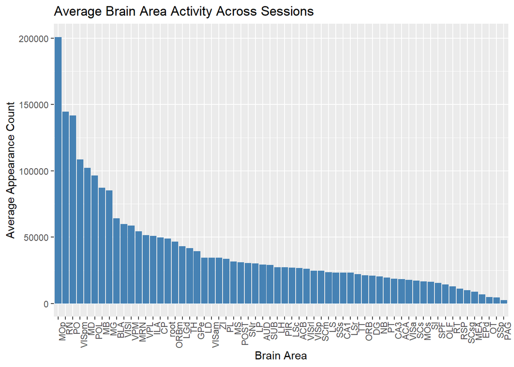

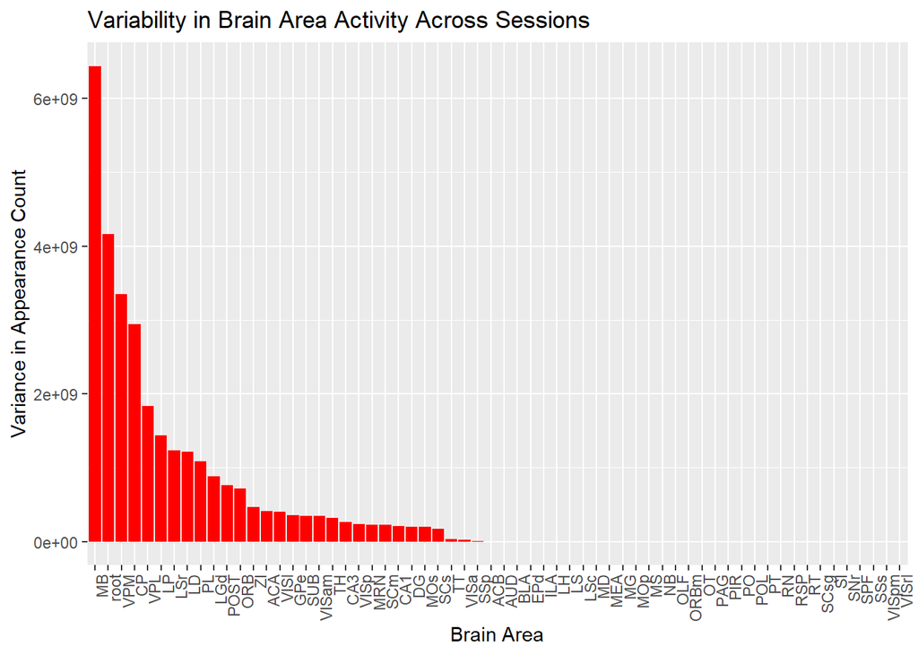